# ford_challenge

Raghavendran Shankar

11 March 2017

## Loading libraries and datasets

```r
library(class) # For knn classification
library(caret) # For confusion matrix
library(rpart) # For decision tree
```

```r
library(rpart.plot) # For visualizing decision tree
ford_train <- read.csv('fordTrain.csv')
ford_test <- read.csv('fordTest.csv')
```

## Data Preprocessing

```r
# Converting the response variable from numeric to categorical data
ford_train$IsAlert <- factor(x = ford_train$IsAlert,levels = c(0,1),labels = c(0,1))

# Removing the first two unused columns and scaling the dataset
ford_train <- ford_train[-c(1,2)]
ford_test <- ford_test[-c(1,2)]

ford_train[-c(1,9,27,29)] <- scale(ford_train[-c(1,9,27,29)])
ford_test[-c(1,9,27,29)] <- scale(ford_test[-c(1,9,27,29)])

ford_train[c(9,27,29)] <- NULL
ford_test[c(9,27,29)] <- NULL
```

## Logistic Regression

Also called as linear classifier that works on binomial data. Prediction on test data is done based on probability values obtained from the training model.

```r
# Fitting the ford_train dataset with logistic regression
logit <- glm(formula = IsAlert ~.,family = binomial,data = ford_train)
logit
```

```
##
## Call:  glm(formula = IsAlert ~ ., family = binomial, data = ford_train)
##
## Coefficients:
## (Intercept)           P1           P2           P3           P4
##    0.431510    -0.105734     0.001995    -0.061749    -0.061576
##          P5           P6           P7           E1           E2
##    0.082655     3.863027     0.492351     0.074606    -0.107890
##          E3           E4           E5           E6           E7
##    0.110598     0.004941    -0.206877    -0.415693    -0.125851
##          E8           E9          E10          E11           V1
##   -0.340647     1.063642     0.143560    -0.007737    -0.554704
##          V2           V3           V4           V5           V6
##   -0.029998    -0.121178    -0.035009    -0.041509     0.214686
##          V8          V10          V11
##   -0.068944    -0.222805     2.006125
##
## Degrees of Freedom: 604328 Total (i.e. Null);  604301 Residual
## Null Deviance:       822700
## Residual Deviance: 574800    AIC: 574900
```

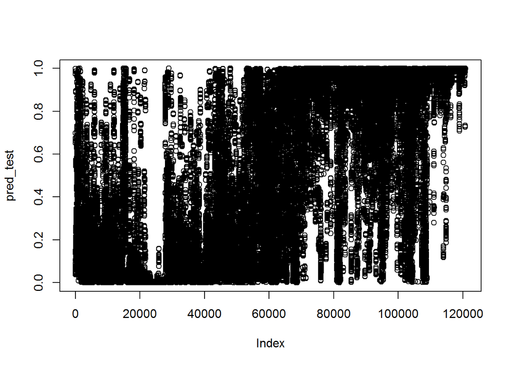

```r
# Prediciton on ford_test based on probability values obtained from the ford_train
pred_test <- predict(object = logit,newdata = ford_test[-c(1)],type = 'response')

log_pred = ifelse(pred_test < 0.5,0,1) # Probability values of less than 50% are assigned 0 i.e not alert

ford_test$IsAlert <- log_pred # Assigining the output values of Log regression to the test set
plot(pred_test)
```

## K Nearest Neighbours

Knn is a classication method used when prediciting and assigning the new data point to the class which is closer( by finding the distance) and is more in number. It follows lazy learner algorithm and takes the whole training data to buuld the model and predict based on the whole dataset.

```r
# Fitting the dataset with knn
knn_pred <- knn(train = ford_train[,-1],test = ford_test[,-1],cl = ford_train[,1],k = 5)

# Creating confusion matrix to compare the output of logistic regression with the knn output
cm = confusionMatrix(ford_test$IsAlert,knn_pred) # comparing logistic and knn models
cm
```

```
## Confusion Matrix and Statistics
##
##           Reference
## Prediction     0     1
##          0 27584 33792
##          1 25137 34327
##
##                Accuracy : 0.5123
##                  95% CI : (0.5095, 0.5152)
##     No Information Rate : 0.5637
##     P-Value [Acc > NIR] : 1
##
##                   Kappa : 0.0266
##  Mcnemar's Test P-Value : <2e-16
##
##             Sensitivity : 0.5232
##             Specificity : 0.5039
##          Pos Pred Value : 0.4494
##          Neg Pred Value : 0.5773
##              Prevalence : 0.4363
##          Detection Rate : 0.2283
##    Detection Prevalence : 0.5079
##       Balanced Accuracy : 0.5136
##
##        'Positive' Class : 0
##
```

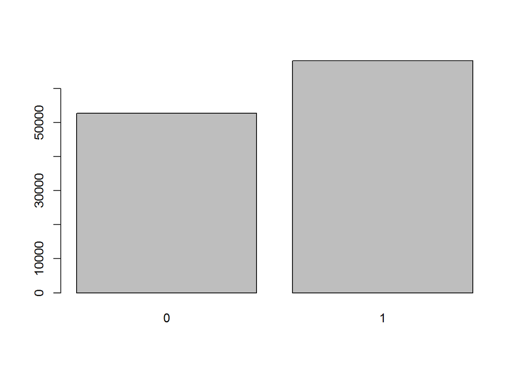

```r
plot(knn_pred)
```

## Decision tree

Decision tree model is based on conditions of the predictors. Unlike Logistic regression or knn, the decision tree does not depend on the distance of data points and hence scaling of dataset is not necessary. The tree can also be pruned to avoid showing the outlier data points which are smal in number.

```r
# Data preprocessing without scaling the variables
ford_train <- read.csv('fordTrain.csv')
ford_test <- read.csv('fordTest.csv')

ford_train$IsAlert <- factor(x = ford_train$IsAlert,levels = c(0,1),labels = c(0,1))

ford_train <- ford_train[-c(1,2)]
ford_test <- ford_test[-c(1,2)]
ford_train[c(9,27,29)] <- NULL
ford_test[c(9,27,29)] <- NULL

ford_test$IsAlert <- log_pred # Assigining the output values of Log regression to the test set

# Fitting and predicitng the dataset using Decision tree
dtree <- rpart(formula = IsAlert ~.,data = ford_train)
tree_pred <- predict(object = dtree,newdata = ford_test[-c(1)],type = 'class')
# Creating confusion matrix to compare the output of logistic regression with the decision tree output
cm = confusionMatrix(ford_test$IsAlert,tree_pred)
cm
```

```
## Confusion Matrix and Statistics
##
##           Reference
## Prediction     0     1
##          0 15460 45916
##          1  7951 51513
##
##                Accuracy : 0.5542
##                  95% CI : (0.5514, 0.557)
##     No Information Rate : 0.8063
##     P-Value [Acc > NIR] : 1
##
##                   Kappa : 0.117
##  Mcnemar's Test P-Value : <2e-16
##
##             Sensitivity : 0.6604
##             Specificity : 0.5287
##          Pos Pred Value : 0.2519
##          Neg Pred Value : 0.8663
##              Prevalence : 0.1937
##          Detection Rate : 0.1279
##    Detection Prevalence : 0.5079
##       Balanced Accuracy : 0.5945
##
##        'Positive' Class : 0
##
```

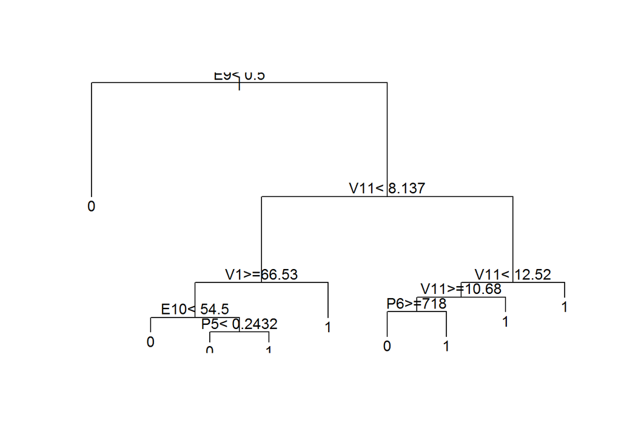

```r
# Visualizing the tree
plot(dtree)
text(dtree)
```

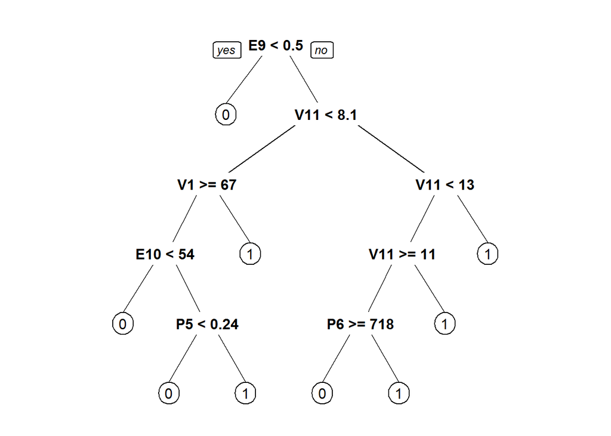

```r
# Data pruning and visualizing the tree
pruned <- prune(dtree,cp=dtree$cptable[which.min(dtree$cptable[,"xerror"]),"CP"])
prp(pruned)
```